# Session 5 Assignment

## Google Analytics with R

```r
library(dplyr, warn.conflicts = FALSE)
library(tidyverse, warn.conflicts = FALSE)
suppressPackageStartupMessages(library(tidyverse)) # suppress startup message
options(dplyr.summarise.inform = FALSE) # Suppress summarise info
library(googleAnalyticsR)
```

```r
ga <- read.csv("~/Projects/DATA104/Assignment 5/ga_data.csv")
```

```r
ga$date <- as.Date(ga$date)
ga$dayOfWeek <- as.factor(ga$dayOfWeek)
ga$hour <- as.integer(ga$hour)
ga$users <- as.integer(ga$users)
ga$sessions <- as.integer(ga$sessions)
ga$bounces <- as.integer(ga$bounces)
```

```r
str(ga)
```

```
## 'data.frame':    720 obs. of  6 variables:
##  $ date     : Date, format: "2020-09-10" "2020-09-10" ...
##  $ dayOfWeek: Factor w/ 7 levels "0","1","2","3",..: 5 5 5 5 5 5 5 5 5 5 ...
##  $ hour     : int  0 1 2 3 4 5 6 7 8 9 ...
##  $ users    : int  0 0 0 0 0 0 0 0 0 0 ...
##  $ sessions : int  0 0 0 0 0 0 0 0 0 0 ...
##  $ bounces  : int  0 0 0 0 0 0 0 0 0 0 ...
```

### Show top and bottom records

```r
head(ga)
```

```
## # A tibble: 6 x 6
##   date       dayOfWeek  hour users sessions bounces
##   <date>     <fct>     <int> <int>    <int>   <int>
## 1 2020-09-10 4             0     0        0       0
## 2 2020-09-10 4             1     0        0       0
## 3 2020-09-10 4             2     0        0       0
## 4 2020-09-10 4             3     0        0       0
## 5 2020-09-10 4             4     0        0       0
## 6 2020-09-10 4             5     0        0       0
```

```r
tail(ga)
```

```
## # A tibble: 6 x 6
##   date       dayOfWeek  hour users sessions bounces
##   <date>     <fct>     <int> <int>    <int>   <int>
## 1 2020-10-09 5            18     0        0       0
## 2 2020-10-09 5            19     0        0       0
## 3 2020-10-09 5            20     0        0       0
## 4 2020-10-09 5            21     0        0       0
## 5 2020-10-09 5            22     0        0       0
## 6 2020-10-09 5            23     0        0       0
```

### Summary Statistics

```r
ga %>%
  select(date, users, sessions, bounces) %>%
  summary()
```

```
##       date                users            sessions          bounces
##  Min.   :2020-09-10   Min.   : 0.0000   Min.   : 0.0000   Min.   : 0.0000
##  1st Qu.:2020-09-17   1st Qu.: 0.0000   1st Qu.: 0.0000   1st Qu.: 0.0000
##  Median :2020-09-24   Median : 0.0000   Median : 0.0000   Median : 0.0000
##  Mean   :2020-09-24   Mean   : 0.4889   Mean   : 0.4875   Mean   : 0.4028
##  3rd Qu.:2020-10-02   3rd Qu.: 0.0000   3rd Qu.: 0.0000   3rd Qu.: 0.0000
##  Max.   :2020-10-09   Max.   :25.0000   Max.   :25.0000   Max.   :21.0000
```

- **Date**: The summary statistics for the date show you with the min/max values the start and end dates of your dataset. We can see we have 30 days of data in this dataset.
- **Users**: The number of total unique users per period. In our case, hourly samples. There were at max 25 users in a single one hour period of time and a min of 0.
- **Sessions**: The max number of sessions in any given hour here was 25, in this case, equal to the number of users. We might see this number be higher than the users on a traditional website; however, we see that each user is essentially visiting it once.
- **Bounces**: The maximum bounce number is 21 showing us that *most* users are bouncing after a single page is viewed. This particular max value is most likely paired with the high of 25 users, suggesting all but 4 of these bounced after landing on the page.

## Session Totals by Date

New data frame for later use, calculating the aggregated number of user sessions by date. This will sum all of the hourly sessions into a single day total.

```r
cum_sesson_totals <- ga %>%
  group_by(date)  %>%
  summarize(total_sessions = sum(sessions), .groups = 'keep')
cum_sesson_totals
```

```
## # A tibble: 30 x 2
##    date       total_sessions
##    <date>              <int>
##  1 2020-09-10              0
##  2 2020-09-11              0
##  3 2020-09-12              0
##  4 2020-09-13              0
##  5 2020-09-14              0
##  6 2020-09-15              0
##  7 2020-09-16              0
##  8 2020-09-17              0
##  9 2020-09-18              0
## 10 2020-09-19              0
## # … with 20 more rows
```

## Sessions Overview

Answering the following questions: * How many days had 0 sessions? * Which days had 0 sessions? * How many days with sessions? * Which days had sessions? * Create a contingency table showing the session counts by date

### How many days had 0 sessions? Which days?

```r
length(which(cum_sesson_totals$total_sessions == 0))
```

```
## [1] 19
```

There were 19 days out of our 30 which had 0 sessions (no activity).

```r
cum_sesson_totals %>%
  filter(total_sessions == 0)
```

```
## # A tibble: 19 x 2
##    date       total_sessions
##    <date>              <int>
##  1 2020-09-10              0
##  2 2020-09-11              0
##  3 2020-09-12              0
##  4 2020-09-13              0
##  5 2020-09-14              0
##  6 2020-09-15              0
##  7 2020-09-16              0
##  8 2020-09-17              0
##  9 2020-09-18              0
## 10 2020-09-19              0
## 11 2020-09-20              0
## 12 2020-09-21              0
## 13 2020-09-22              0
## 14 2020-09-23              0
## 15 2020-09-25              0
## 16 2020-09-26              0
## 17 2020-09-28              0
## 18 2020-10-01              0
## 19 2020-10-03              0
```

### How many days with 1 or more sessions? Which days?

```r
length(which(cum_sesson_totals$total_sessions >= 1))
```

```
## [1] 11
```

There were 11 days (out of 30) which had at least one session.

```r
at_least_one_session <- cum_sesson_totals %>%
  filter(total_sessions >= 1)

at_least_one_session
```

```
## # A tibble: 11 x 2
##    date       total_sessions
##    <date>              <int>
##  1 2020-09-24              3
##  2 2020-09-27              4
##  3 2020-09-29              1
##  4 2020-09-30              2
##  5 2020-10-02              1
##  6 2020-10-04              1
##  7 2020-10-05            139
##  8 2020-10-06             98
##  9 2020-10-07             34
## 10 2020-10-08             55
## 11 2020-10-09             13
```

### Contingency table with total sessions by date (for dates with 1 or more sessions)

Contingency tables (also called crosstabs or two-way tables) are used in statistics to summarize the relationship between several categorical variables. A contingency table is a special type of frequency distribution table, where two variables are shown simultaneously.[1]

[1] https://www.statisticshowto.com/what-is-a-contingency-table/

```r
# Contingency table that shows the days that have at least 1 session
addmargins(with(at_least_one_session, table(date, total_sessions, dnn = c('date', 'total_sessions'))))
```

```
##             total_sessions
## date          1  2  3  4 13 34 55 98 139 Sum
##   2020-09-24  0  0  1  0  0  0  0  0   0   1
##   2020-09-27  0  0  0  1  0  0  0  0   0   1
##   2020-09-29  1  0  0  0  0  0  0  0   0   1
##   2020-09-30  0  1  0  0  0  0  0  0   0   1
##   2020-10-02  1  0  0  0  0  0  0  0   0   1
##   2020-10-04  1  0  0  0  0  0  0  0   0   1
##   2020-10-05  0  0  0  0  0  0  0  0   1   1
##   2020-10-06  0  0  0  0  0  0  0  1   0   1
##   2020-10-07  0  0  0  0  0  1  0  0   0   1
##   2020-10-08  0  0  0  0  0  0  1  0   0   1
##   2020-10-09  0  0  0  0  1  0  0  0   0   1
##   Sum         3  1  1  1  1  1  1  1   1  11
```

According to the contingency table, we can sum the total_sessions multiplied by the number of occurances on different days (as shown by the sum row for the columns). Given that we have:

`(3 * 1) + 2 + 3 + 4 + 13 + 34 + 55 + 98 + 139 = 351` total sessions across 11 days.

We can quickly validate that by creating summarizing our original data/number of sessions.

```r
ga %>%
  summarize(total_sessions = sum(sessions), .groups = 'keep')
```

```
## # A tibble: 1 x 1
##   total_sessions
##            <int>
## 1            351
```

There was in fact 351 sessions accross those 11 days.

## Number of Sessions by Day

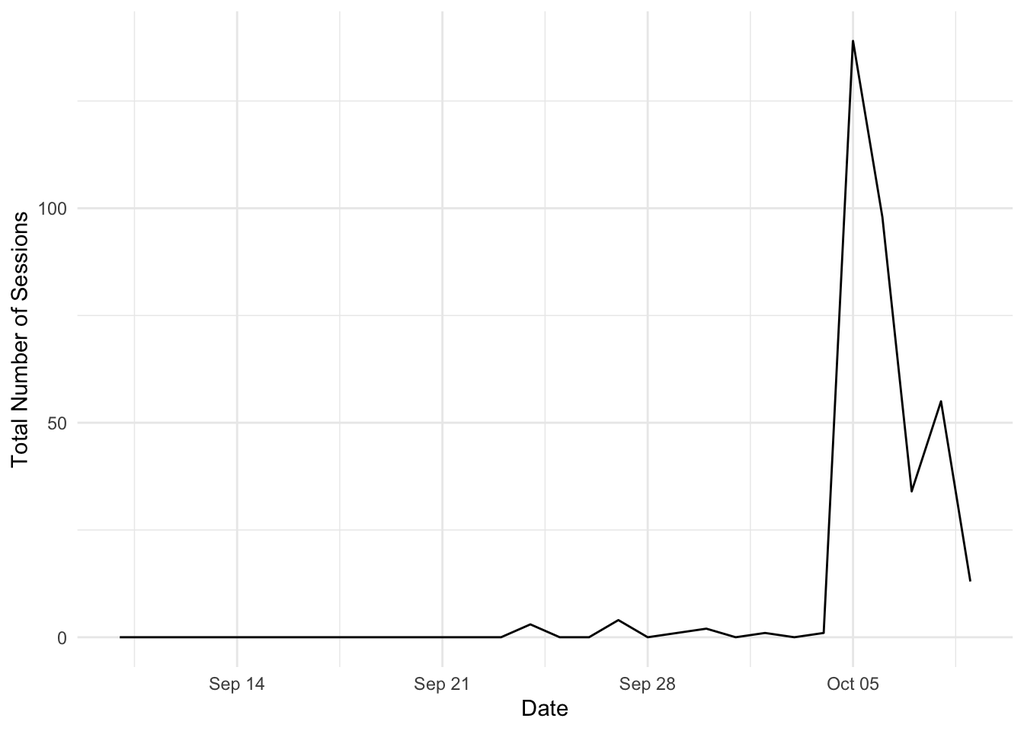

```r
ggplot(cum_sesson_totals, mapping = aes(x = date, y = total_sessions)) +
  geom_line(color = 'black') +
  xlab("Date") +
  ylab("Total Number of Sessions") +
  theme_minimal()
```

The page was mostly idle until October 5th, the was shared on various social media sites and produced an influx of new users. The most massive spike was on the 5th, then dropping from there over the subsequent days.

## Scatter Plot with a Trend Line of sessions

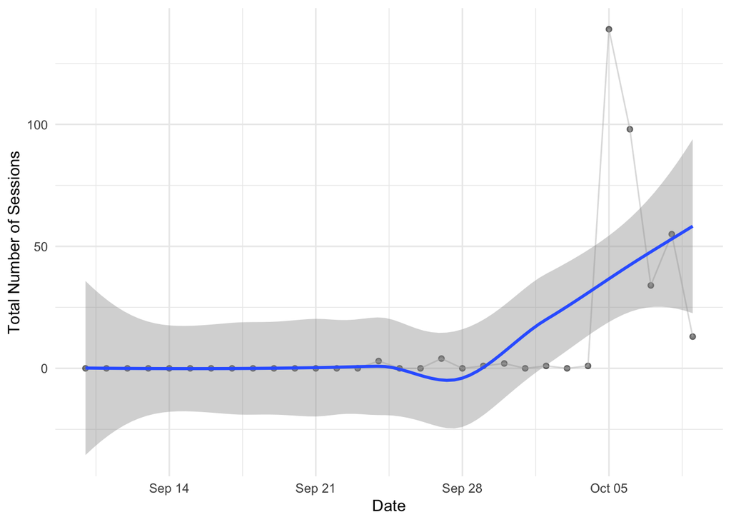

```r
ggplot(cum_sesson_totals, mapping = aes(x = date, y = total_sessions)) +
  geom_point(color = 'black', alpha = 0.5) +
  geom_line(color = 'gray', alpha = 0.5) +
  geom_smooth() +
  xlab("Date") +
  ylab("Total Number of Sessions") +
  theme_minimal()
```

Given the massive spike in users from October 5th, the trend line appears to have strong upward momentum. However, we can see that the number of sessions had been dropping, giving us less confidence (regardless of the confidence interval shown) that the trend will continue.

## Create a new dataframe called cum_dayofweek_totals, with session totals by date and dayOfWeek

```r
cum_dayofweek_totals = ga %>%
  group_by(date, dayOfWeek)  %>%
  summarize(total_sessions = sum(sessions), .groups = 'keep')
```

## Create boxplots showing the number of sessions by day of week (use cum_dayofweek_totals)

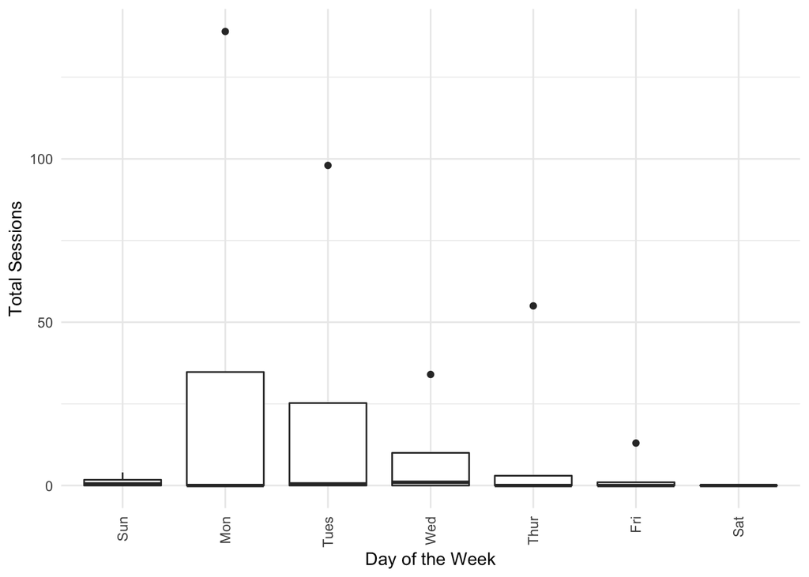

```r
ggplot(cum_dayofweek_totals, aes(x = dayOfWeek, y = total_sessions)) +
  geom_boxplot() +
  scale_x_discrete(labels = c('Sun', 'Mon', 'Tues', 'Wed', 'Thur', 'Fri', 'Sat'),
                   guide = guide_axis(angle = 90)) +
  xlab("Day of the Week") +
  ylab("Total Sessions") +
  theme_minimal()
```

## User Totals by Hour and ‘Day of Week’

```r
cum_user_totals = ga %>%
  select(hour, dayOfWeek, users)  %>%
  group_by(hour, dayOfWeek, users) %>%
  summarize(total_users = sum(users), .groups = 'keep')

cum_user_totals
```

```
## # A tibble: 251 x 4
##     hour dayOfWeek users total_users
##    <int> <fct>     <int>       <int>
##  1     0 0             0           0
##  2     0 1             0           0
##  3     0 2             0           0
##  4     0 2             2           2
##  5     0 3             0           0
##  6     0 4             0           0
##  7     0 5             0           0
##  8     0 6             0           0
##  9     1 0             0           0
## 10     1 1             0           0
## # … with 241 more rows
```

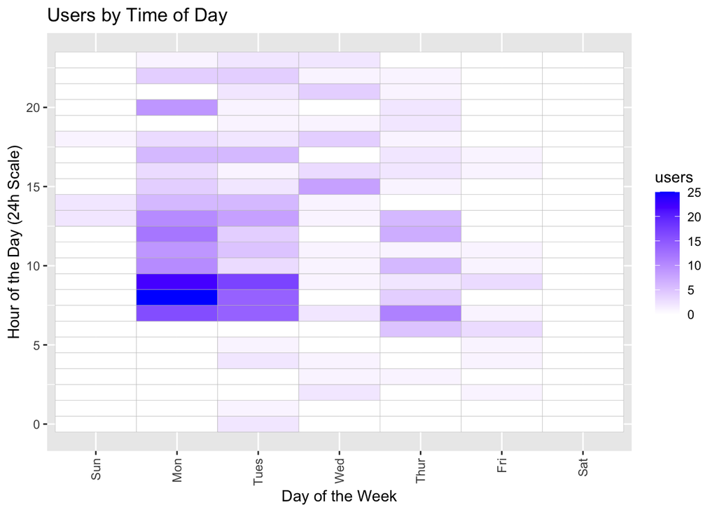

```r
ggplot(cum_user_totals, aes(x = dayOfWeek, y = hour, fill = users)) +
  geom_tile(color = "gray") +
  scale_fill_gradient(low="white", high="blue") +
  theme_gray() +
  scale_x_discrete(labels = c('Sun', 'Mon', 'Tues', 'Wed', 'Thur', 'Fri', 'Sat'),
                   guide = guide_axis(angle = 90)) +
  ggtitle("Users by Time of Day") +
  xlab("Day of the Week") +
  ylab("Hour of the Day (24h Scale)")
```

The heat map above shows which days and hours were most active for users. As we saw in the box plots, Monday was bar far the busiest day. In the heatmap, we see all user’s activity displayed via color intensity for each hour. However, different from what we could see with the box plots, we can visualize which hour was the most active.

We can see around 7 A.M. on Monday, the activity picked up with a spike/max users at 8:00 and into the 9:00 hour. This pattern suggests that whatever drove new user acquisition happened early in the morning and carried through the early afternoon. Another cohort of approximately 10-15 users happened at 8:00 P.M., potentially when other parts of the world started to become active.

On Tuesday, the morning saw similar activity, however, with less intensity. On Wednesday, the pattern was different, with minimal movement in the morning. Still, a small ramp up at 3:00 in the afternoon, potentially signaling that action that drove new user activity happened later in the day. Finally, Thursday reverted to the morning pattern, again, with less intensity.